# Information Visualisation - Final Project

Thaheer

2026-11-24

```r
library(tidyverse)
library(scales)
library(patchwork)
library(GGally)
library(sf)
library(tidytext)
library(plotly)
library(knitr)
library(ggwordcloud)
```

# 1. Introduction: question and dataset

Which London boroughs attract the most Airbnb guest demand, and how does that demand relate to price, seasonal patterns in reviews, and what guests say about their stays?

**Source** This project reuses the detailed London listings file examined in the earlier Technical Report, together with two companion files from the same Inside Airbnb release: the borough boundary file and the detailed guest reviews file. All three are published by Inside Airbnb, which compiles publicly available Airbnb data and distributes it under a Creative Commons Attribution 4.0 licence.

**Structure** The listings file contains 91,954 listings, one row per property, scraped between 18 and 23 September 2026. The reviews file contains 2,323,969 reviews, one row per guest review, each carrying the date it was posted and the review’s text. The boundary file contains 33 polygon features, one per London borough.

**Variables used** From the listings file this analysis uses each listing’s borough, room type, advertised price, and guest-capacity fields. From the reviews file it uses the review date and comment text. From the boundary file it uses each borough’s name and boundary, joined to the other two files on borough name.

**Scope** Rather than all 33 boroughs, this project focuses on the ten boroughs with the highest total review volume — used here as a reproducible proxy for guest demand, rather than a subjective choice of “popular” or “touristy” areas.

**Relationship to the earlier Technical Report** This project builds on the Technical Report submitted for CW1, which compared advertised prices between entire-home and private-room listings in three boroughs (Westminster, Hackney and Croydon) and found a substantial price gap between the two room types. That analysis is not repeated here. Instead, this project widens the scope to the ten highest-demand boroughs across London, reframes the investigation around guest demand, and introduces two new data sources — guest reviews and borough boundaries — together with four analytical techniques not used in the earlier report: spatial, time-series, text and interactive visualisation.

[output not shown]

Because of these limitations, the findings in this report describe patterns in advertised prices and guest review activity for the ten boroughs studied, not a complete or unbiased measure of true demand, occupancy, or visitor experience across London.

# 2. Data preparation and workflow

```r
listings <- read_csv("data/listings.csv", show_col_types = FALSE)
reviews  <- read_csv("data/reviews.csv", show_col_types = FALSE)
boroughs <- st_read("data/neighbourhoods.geojson", quiet = TRUE)

glimpse(listings)
```

```
## Rows: 91,954
## Columns: 90
## $ id                                           <dbl> 11551, 13913, 15400, 2432…
## $ listing_url                                  <chr> "https://www.airbnb.com/r…
## $ scrape_id                                    <dbl> 2.026092e+13, 2.026092e+1…
## $ last_scraped                                 <date> 2026-09-19, 2026-09-19, …
## $ source                                       <chr> NA, NA, NA, NA, "previous…
## $ name                                         <chr> "Artistic London Pied-à-T…
## $ description                                  <chr> "Live like a local in thi…
## $ neighborhood_overview                        <lgl> NA, NA, NA, NA, NA, NA, N…
## $ picture_url                                  <chr> "https://a0.muscache.com/…
## $ host_id                                      <dbl> 43039, 54730, 60302, 4175…
## $ host_url                                     <chr> "https://www.airbnb.com/u…
## $ host_profile_id                              <dbl> 1.462507e+18, 1.462508e+1…
## $ host_profile_url                             <chr> "https://www.airbnb.com/u…
```

[output cut: 77 more lines]

```r
glimpse(reviews)
```

```
## Rows: 2,323,969
## Columns: 6
## $ listing_id    <dbl> 11551, 11551, 11551, 11551, 11551, 11551, 11551, 11551, …
## $ id            <dbl> 30672, 32236, 41044, 48926, 58352, 66216, 79600, 89501, …
## $ date          <date> 2010-03-21, 2010-03-29, 2010-05-09, 2010-06-01, 2010-06…
## $ reviewer_id   <dbl> 93896, 97890, 104133, 122714, 111543, 165158, 190950, 15…
## $ reviewer_name <chr> "Shar-Lyn", "Zane", "Chase", "John & Sylvia", "Monique",…
## $ comments      <chr> "The flat was bright, comfortable and clean and Adriano …
```

```r
boroughs
```

```
## Simple feature collection with 33 features and 2 fields
## Geometry type: MULTIPOLYGON
## Dimension:     XY
## Bounding box:  xmin: -0.510356 ymin: 51.28676 xmax: 0.334044 ymax: 51.69188
## Geodetic CRS:  WGS 84
## First 10 features:
##           neighbourhood neighbourhood_group                       geometry
## 1  Kingston upon Thames                <NA> MULTIPOLYGON (((-0.330656 5...
## 2               Croydon                <NA> MULTIPOLYGON (((-0.063994 5...
## 3               Bromley                <NA> MULTIPOLYGON (((0.012158 51...
## 4              Hounslow                <NA> MULTIPOLYGON (((-0.244539 5...
## 5                Ealing                <NA> MULTIPOLYGON (((-0.411812 5...
## 6              Havering                <NA> MULTIPOLYGON (((0.158722 51...
## 7            Hillingdon                <NA> MULTIPOLYGON (((-0.40405 51...
## 8                Harrow                <NA> MULTIPOLYGON (((-0.40405 51...
## 9                 Brent                <NA> MULTIPOLYGON (((-0.196544 5...
## 10               Barnet                <NA> MULTIPOLYGON (((-0.199872 5...
```

```r
# Convert price from "$267.50" text to a usable number
listings <- listings |>
  mutate(price = parse_number(price))

# Attach each review's borough via its listing, then count reviews per borough
# -- this count is our demand proxy
borough_review_volume <- reviews |>
  left_join(listings |> select(id, neighbourhood_cleansed),
            by = c("listing_id" = "id")) |>
  count(neighbourhood_cleansed, name = "review_count", sort = TRUE)

borough_review_volume
```

```
## # A tibble: 33 × 2
##    neighbourhood_cleansed review_count
##    <chr>                         <int>
##  1 Westminster                  331254
##  2 Camden                       203575
##  3 Kensington and Chelsea       172489
##  4 Tower Hamlets                172014
##  5 Southwark                    152221
##  6 Lambeth                      145229
##  7 Islington                    139545
##  8 Hackney                      126356
##  9 Hammersmith and Fulham       108000
## 10 Wandsworth                    95843
## # ℹ 23 more rows
```

```r
# Keep the 10 boroughs with the most reviews
top_boroughs <- borough_review_volume |>
  slice_max(review_count, n = 10) |>
  pull(neighbourhood_cleansed)

top_boroughs
```

```
##  [1] "Westminster"            "Camden"                 "Kensington and Chelsea"
##  [4] "Tower Hamlets"          "Southwark"              "Lambeth"
##  [7] "Islington"              "Hackney"                "Hammersmith and Fulham"
## [10] "Wandsworth"
```

```r
# Filter all three datasets to this scope
listings_scope <- listings |>
  filter(neighbourhood_cleansed %in% top_boroughs)

reviews_scope <- reviews |>
  semi_join(listings_scope, by = c("listing_id" = "id"))

boroughs_scope <- boroughs |>
  filter(neighbourhood %in% top_boroughs)

dim(listings_scope)
```

```
## [1] 59214    90
```

```r
dim(reviews_scope)
```

```
## [1] 1646526       6
```

```r
boroughs_scope
```

```
## Simple feature collection with 10 features and 2 fields
## Geometry type: MULTIPOLYGON
## Dimension:     XY
## Bounding box:  xmin: -0.25909 ymin: 51.41099 xmax: 0.009233 ymax: 51.57779
## Geodetic CRS:  WGS 84
##             neighbourhood neighbourhood_group                       geometry
## 1                 Lambeth                <NA> MULTIPOLYGON (((-0.128431 5...
## 2               Southwark                <NA> MULTIPOLYGON (((-0.108899 5...
## 3              Wandsworth                <NA> MULTIPOLYGON (((-0.223402 5...
## 4  Hammersmith and Fulham                <NA> MULTIPOLYGON (((-0.244539 5...
## 5  Kensington and Chelsea                <NA> MULTIPOLYGON (((-0.183857 5...
## 6             Westminster                <NA> MULTIPOLYGON (((-0.149979 5...
## 7                  Camden                <NA> MULTIPOLYGON (((-0.14239 51...
## 8           Tower Hamlets                <NA> MULTIPOLYGON (((-0.079354 5...
## 9               Islington                <NA> MULTIPOLYGON (((-0.138369 5...
## 10                Hackney                <NA> MULTIPOLYGON (((-0.097639 5...
```

```r
borough_review_volume |>
  filter(neighbourhood_cleansed %in% top_boroughs) |>
  arrange(desc(review_count)) |>
  rename(Borough = neighbourhood_cleansed, `Review count` = review_count) |>
  kable(format.args = list(big.mark = ","),
        caption = "The ten boroughs selected by total review volume.")
```

The ten boroughs selected by total review volume.

| Borough | Review count |
| --- | --- |
| Westminster | 331,254 |
| Camden | 203,575 |
| Kensington and Chelsea | 172,489 |
| Tower Hamlets | 172,014 |
| Southwark | 152,221 |
| Lambeth | 145,229 |
| Islington | 139,545 |
| Hackney | 126,356 |
| Hammersmith and Fulham | 108,000 |
| Wandsworth | 95,843 |

# 3. Visual analysis

## 3.1 Spatial (where is demand concentrated)

```r
borough_summary <- listings_scope |>
  group_by(neighbourhood_cleansed) |>
  summarise(median_price = median(price, na.rm = TRUE),
            n_listings = n()) |>
  left_join(borough_review_volume, by = "neighbourhood_cleansed")

map_data <- boroughs_scope |>
  left_join(borough_summary, by = c("neighbourhood" = "neighbourhood_cleansed"))

map_data
```

```
## Simple feature collection with 10 features and 5 fields
## Geometry type: MULTIPOLYGON
## Dimension:     XY
## Bounding box:  xmin: -0.25909 ymin: 51.41099 xmax: 0.009233 ymax: 51.57779
## Geodetic CRS:  WGS 84
##             neighbourhood neighbourhood_group median_price n_listings
## 1                 Lambeth                <NA>      153.200       4968
## 2               Southwark                <NA>      158.000       5126
## 3              Wandsworth                <NA>      185.210       4611
## 4  Hammersmith and Fulham                <NA>      184.000       4065
## 5  Kensington and Chelsea                <NA>      273.180       6271
## 6             Westminster                <NA>      282.000      10825
## 7                  Camden                <NA>      207.670       6178
## 8           Tower Hamlets                <NA>      161.500       6723
## 9               Islington                <NA>      182.000       4707
## 10                Hackney                <NA>      164.465       5740
##    review_count                       geometry
## 1        145229 MULTIPOLYGON (((-0.128431 5...
## 2        152221 MULTIPOLYGON (((-0.108899 5...
## 3         95843 MULTIPOLYGON (((-0.223402 5...
## 4        108000 MULTIPOLYGON (((-0.244539 5...
## 5        172489 MULTIPOLYGON (((-0.183857 5...
## 6        331254 MULTIPOLYGON (((-0.149979 5...
## 7        203575 MULTIPOLYGON (((-0.14239 51...
## 8        172014 MULTIPOLYGON (((-0.079354 5...
## 9        139545 MULTIPOLYGON (((-0.138369 5...
## 10       126356 MULTIPOLYGON (((-0.097639 5...
```

```r
p1 <- ggplot(map_data) +
  geom_sf(aes(fill = review_count,
              text = paste0(neighbourhood, ": ", comma(review_count), " reviews")),
          colour = "white", linewidth = 0.3) +
  scale_fill_viridis_c(option = "plasma", labels = comma) +
  labs(fill = "Total reviews") +
  theme_minimal() +
  theme(axis.text = element_blank(), axis.ticks = element_blank(),
        panel.grid = element_blank())

ggplotly(p1, tooltip = "text")
```

[interactive chart not shown]

**Figure 1** shows Westminster has by far the highest total review volume (331,254) among the ten boroughs studied, consistent with its dominant position in CW1’s price comparison. This total is partly a function of market size, however — Westminster also has the most listings in scope (10,825) — so part of its lead reflects supply rather than guest demand. This is exactly the distinction Week 8 draws between a count and a rate: a count answers “how many events”, a rate answers “how many relative to exposure”, and a large count can simply reflect a large underlying population. Adjusting for this by dividing reviews by listings, Camden has the highest reviews-per-listing (32.95, versus Westminster’s 30.60) despite having under two-thirds as many listings (6,178) — its individual properties attract disproportionately more guest activity. Read together, the map and the rate table make one argument: Westminster is the larger market, but Camden’s listings are, on average, the more in-demand ones.

```r
map_data |>
  st_drop_geometry() |>
  mutate(reviews_per_listing = review_count / n_listings) |>
  arrange(desc(reviews_per_listing)) |>
  select(neighbourhood, review_count, n_listings, reviews_per_listing)
```

```
##             neighbourhood review_count n_listings reviews_per_listing
## 1                  Camden       203575       6178            32.95160
## 2             Westminster       331254      10825            30.60083
## 3               Southwark       152221       5126            29.69586
## 4               Islington       139545       4707            29.64627
## 5                 Lambeth       145229       4968            29.23289
## 6  Kensington and Chelsea       172489       6271            27.50582
## 7  Hammersmith and Fulham       108000       4065            26.56827
## 8           Tower Hamlets       172014       6723            25.58590
## 9                 Hackney       126356       5740            22.01324
## 10             Wandsworth        95843       4611            20.78573
```

```r
p2 <- ggplot(map_data) +
  geom_sf(aes(fill = median_price,
              text = paste0(neighbourhood, ": £", round(median_price), " median price")),
          colour = "white", linewidth = 0.3) +
  scale_fill_viridis_c(option = "viridis", labels = label_dollar(prefix = "£")) +
  labs(fill = "Median price\n(£/night)") +
  theme_minimal()

ggplotly(p2, tooltip = "text") |>
  layout(xaxis = list(visible = FALSE, showgrid = FALSE),
         yaxis = list(visible = FALSE, showgrid = FALSE))
```

[interactive chart not shown]

## 3.2 Multivariate

```r
corr_vars <- listings_scope |>
  select(price, accommodates, bedrooms, beds, review_scores_rating,
         number_of_reviews, availability_365) |>
  drop_na()

corr_matrix <- cor(corr_vars, method = "spearman")

corr_long <- corr_matrix |>
  as.data.frame() |>
  rownames_to_column("var1") |>
  pivot_longer(-var1, names_to = "var2", values_to = "correlation")
```

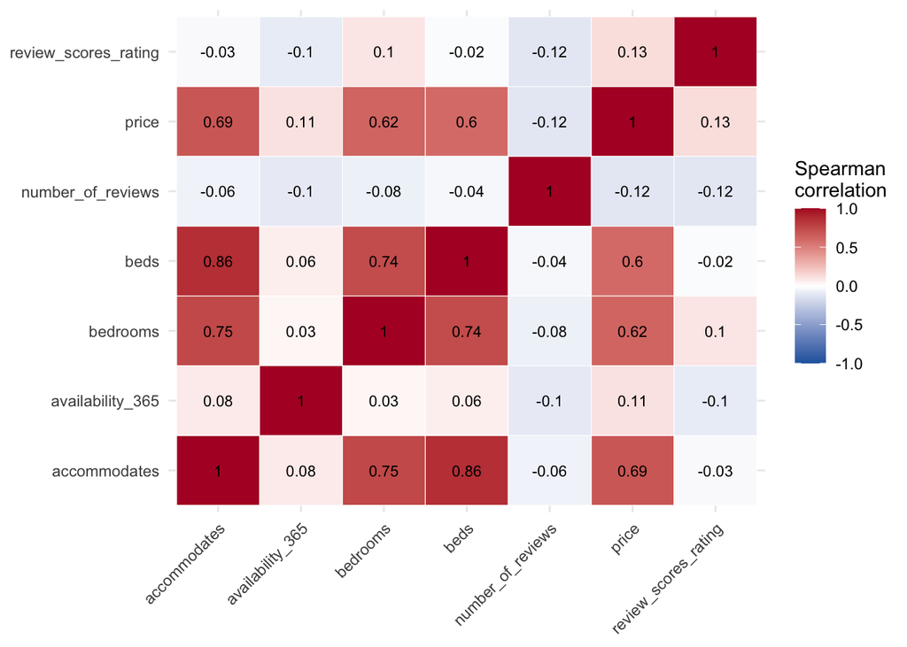

Figure 3: Spearman correlation between price and listing characteristics.

```r
ggplot(corr_long, aes(var1, var2, fill = correlation)) +
  geom_tile(colour = "white") +
  geom_text(aes(label = round(correlation, 2)), size = 3) +
  scale_fill_gradient2(low = "#2166AC", mid = "white", high = "#B2182B",
                       midpoint = 0, limits = c(-1, 1)) +
  labs(x = NULL, y = NULL, fill = "Spearman\ncorrelation") +
  theme_minimal() +
  theme(axis.text.x = element_text(angle = 45, hjust = 1))
```

```r
range(reviews_scope$date, na.rm = TRUE)
```

```
## [1] "2009-12-21" "2026-09-22"
```

```r
sum(is.na(reviews_scope$date))
```

```
## [1] 0
```

## 3.3 Time-series

```r
monthly_reviews <- reviews_scope |>
  mutate(month = floor_date(date, "month")) |>
  count(month, name = "review_count")

range(monthly_reviews$month)
```

```
## [1] "2009-12-01" "2026-09-01"
```

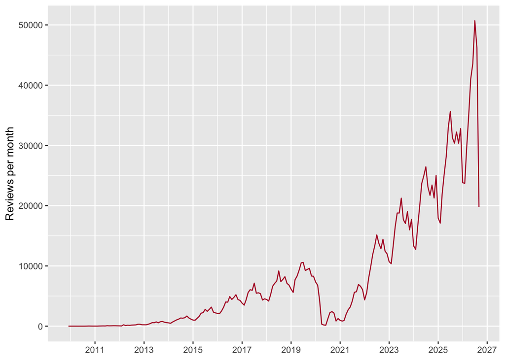

Figure 4: Monthly review volume across the ten boroughs, 2009-2026.

```r
ggplot(monthly_reviews, aes(month, review_count)) +
  geom_line(colour = "#B2182B", linewidth = 0.5) +
  scale_x_date(date_breaks = "2 years", date_labels = "%Y") +
  labs(x = NULL, y = "Reviews per month")
```

**Figure 4** shows guest review activity across the ten boroughs was minimal through 2010–2014 — consistent with Airbnb’s early growth in London — then rose gradually through 2015–2019, reaching roughly 10,000 reviews per month by its pre-pandemic peak. A sharp, near-total collapse follows in 2020, down to close to zero, matching the well-documented effect of COVID-19 travel restrictions on short-term lets rather than any issue with the data itself. Recovery from 2021 is not just a return to the old trend but a steep acceleration past it: by 2025–2026 monthly review volume regularly exceeds 30,000–50,000, roughly four to five times the 2019 peak, suggesting substantially higher guest activity in this ten-borough scope than before the pandemic. One caution before reading too much into the final point: the last month (September 2026) shows an apparent sharp drop, but the listings file documents a scrape mid-month (18–23 September), so that month’s review count is based on a partial month of data — a data-collection artifact, not evidence the growth has reversed.

```r
seasonal_reviews <- reviews_scope |>
  filter(date >= as.Date("2022-01-01"), date < as.Date("2026-01-01")) |>
  mutate(year = year(date), month_num = month(date, label = TRUE)) |>
  count(year, month_num, name = "review_count") |>
  group_by(month_num) |>
  summarise(avg_reviews = mean(review_count), .groups = "drop")
```

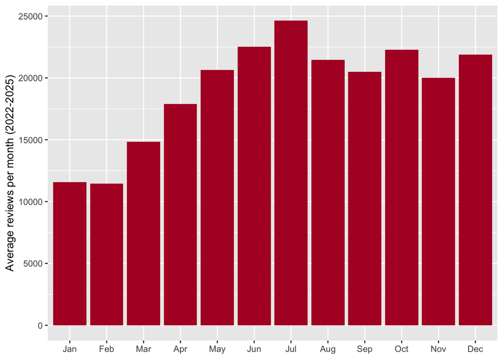

Figure 5: Average monthly reviews by calendar month, 2022-2025.

```r
ggplot(seasonal_reviews, aes(month_num, avg_reviews)) +
  geom_col(fill = "#B2182B") +
  labs(x = NULL, y = "Average reviews per month (2022-2025)")
```

**Figure 5** shows a clear seasonal pattern within a typical year: average monthly reviews are lowest in January and February (around 11,500) — roughly half the July peak (24,600) — then climb steadily from March through June before peaking in mid-summer. Autumn months stay comparatively high, between 20,000 and 22,200, rather than tailing off sharply after summer, suggesting the ten highest-demand boroughs sustain elevated guest activity well beyond the traditional tourist season. This matches general London tourism seasonality — a quiet winter low point, particularly after the December holiday period — and confirms the research question’s “seasonal patterns” component is a genuine, recurring annual cycle, distinct from the year-on-year growth trend already shown in Figure 4.

## 3.4 Text Visualisation

```r
set.seed(7413)

reviews_sample <- reviews_scope |>
  slice_sample(n = 100000)

word_freq_raw <- reviews_sample |>
  unnest_tokens(word, comments) |>
  anti_join(stop_words, by = "word") |>
  count(word, sort = TRUE)
```

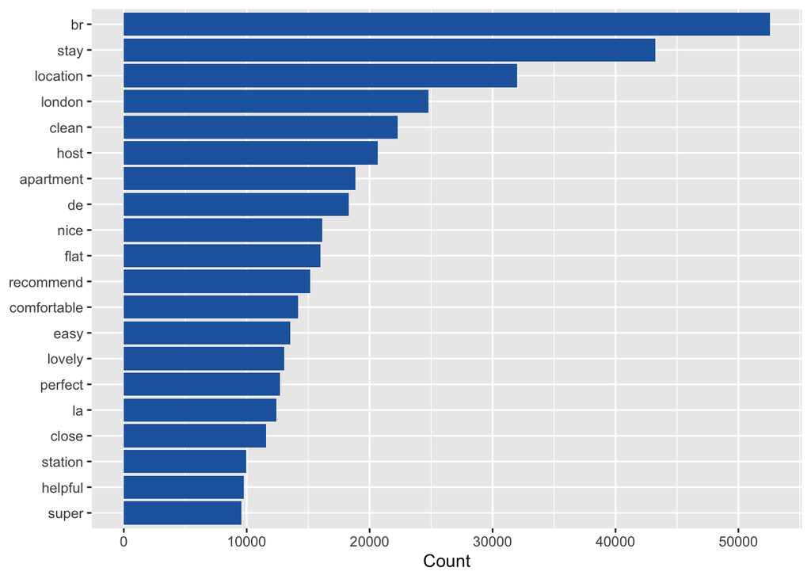

Most frequent words before cleaning.

```r
word_freq_raw |>
  slice_max(n, n = 20) |>
  ggplot(aes(n, fct_reorder(word, n))) +
  geom_col(fill = "#2166AC") +
  labs(x = "Count", y = NULL)
```

The standard stop_words lexicon is English-only, but this chart shows exactly why that isn’t enough on its own: “br” (52,559 occurrences, HTML markup leakage from Airbnb’s own formatting, not something a guest wrote) sits at the very top, and “de” and “la” — French and Spanish function words — also make the top 20, because these reviews are genuinely multilingual. All three are removed explicitly below, rather than silently, so the decision is visible rather than just asserted.

```r
custom_stop_words <- tibble(word = c("br", "de", "la", "le", "el", "en", "et"))

word_freq <- word_freq_raw |>
  anti_join(custom_stop_words, by = "word")
```

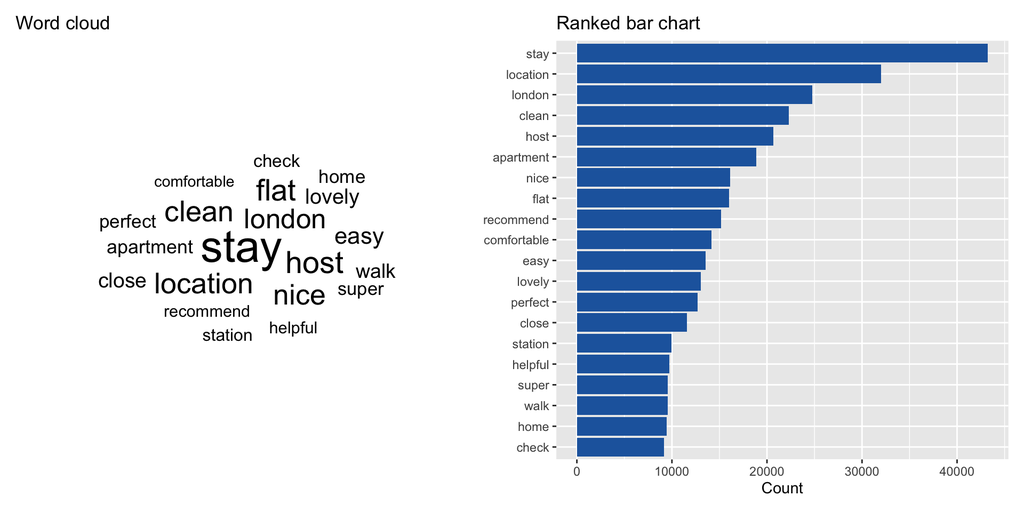

Figure 6: Top 20 review words after cleaning – word cloud versus ranked bar chart.

```r
top20 <- word_freq |> slice_max(n, n = 20)

p_cloud <- ggplot(top20, aes(label = word, size = n)) +
  geom_text_wordcloud_area() +
  scale_size_area(max_size = 20) +
  theme_minimal() +
  labs(title = "Word cloud")

p_bar <- ggplot(top20, aes(n, fct_reorder(word, n))) +
  geom_col(fill = "#2166AC") +
  labs(x = "Count", y = NULL, title = "Ranked bar chart")

p_cloud + p_bar
```

## 3.5 Text sentiment by borough

```r
reviews_with_borough <- reviews_sample |>
  left_join(listings_scope |> select(id, neighbourhood_cleansed),
            by = c("listing_id" = "id"))

bing_sentiments <- get_sentiments("bing") |>
  filter(!word %in% c("die", "tout", "sin"))

borough_sentiment <- reviews_with_borough |>
  unnest_tokens(word, comments) |>
  inner_join(bing_sentiments, by = "word") |>
  count(neighbourhood_cleansed, sentiment) |>
  pivot_wider(names_from = sentiment, values_from = n, values_fill = 0) |>
  mutate(pct_positive = positive / (positive + negative) * 100,
         deviation = pct_positive - 50)

borough_sentiment_long <- borough_sentiment |>
  mutate(pct_negative = 100 - pct_positive,
         neighbourhood_cleansed = fct_reorder(neighbourhood_cleansed, pct_positive)) |>
  select(neighbourhood_cleansed, pct_positive, pct_negative) |>
  pivot_longer(c(pct_positive, pct_negative), names_to = "sentiment", values_to = "pct") |>
  mutate(sentiment = factor(if_else(sentiment == "pct_positive", "Positive", "Negative"),
                             levels = c("Negative", "Positive")))
```

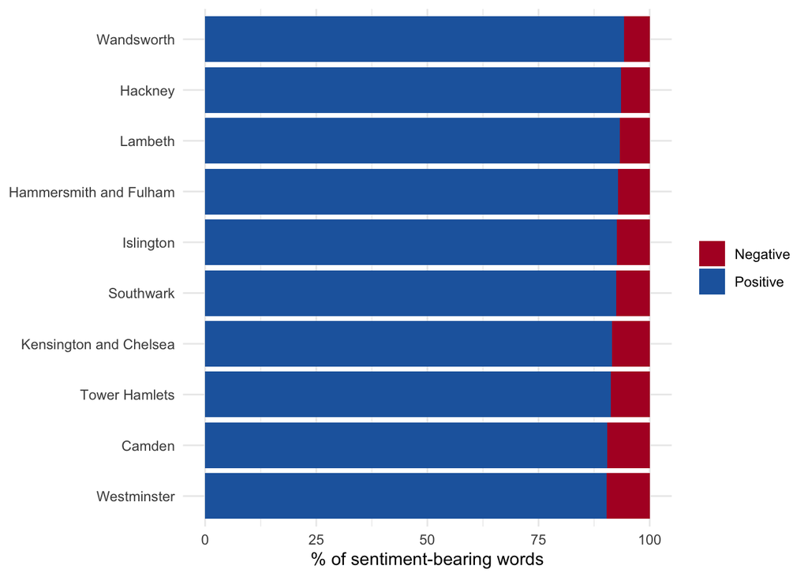

Figure 7: Guest sentiment by borough – share of sentiment-bearing words that are positive vs negative.

```r
ggplot(borough_sentiment_long, aes(x = neighbourhood_cleansed, y = pct, fill = sentiment)) +
  geom_col() +
  coord_flip() +
  scale_fill_manual(values = c(Positive = "#2166AC", Negative = "#B2182B")) +
  labs(x = NULL, y = "% of sentiment-bearing words", fill = NULL) +
  theme_minimal()
```

```r
sentiment_words <- reviews_with_borough |>
  unnest_tokens(word, comments) |>
  inner_join(bing_sentiments, by = "word") |>
  count(word, sentiment, sort = TRUE)

top_positive <- sentiment_words |> filter(sentiment == "positive") |> slice_max(n, n = 10)
top_negative <- sentiment_words |> filter(sentiment == "negative") |> slice_max(n, n = 10)
```

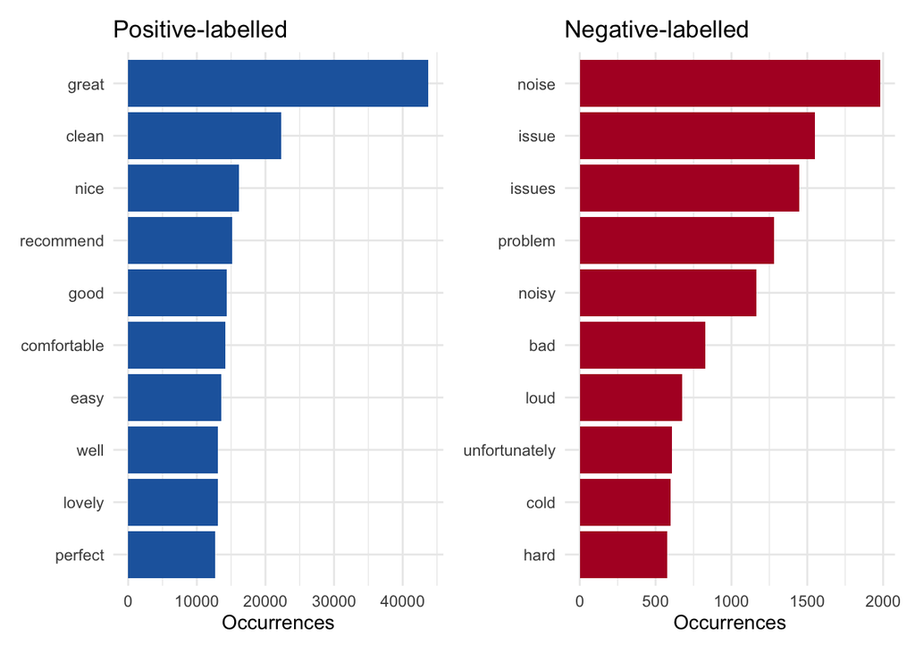

Words contributing most to the sentiment count.

```r
p_pos <- ggplot(top_positive, aes(reorder(word, n), n)) +
  geom_col(fill = "#2166AC") +
  coord_flip() +
  labs(title = "Positive-labelled", x = NULL, y = "Occurrences") +
  theme_minimal()

p_neg <- ggplot(top_negative, aes(reorder(word, n), n)) +
  geom_col(fill = "#B2182B") +
  coord_flip() +
  labs(title = "Negative-labelled", x = NULL, y = "Occurrences") +
  theme_minimal()

p_pos + p_neg
```